# S1.10 Code used to develop and present GLMM results

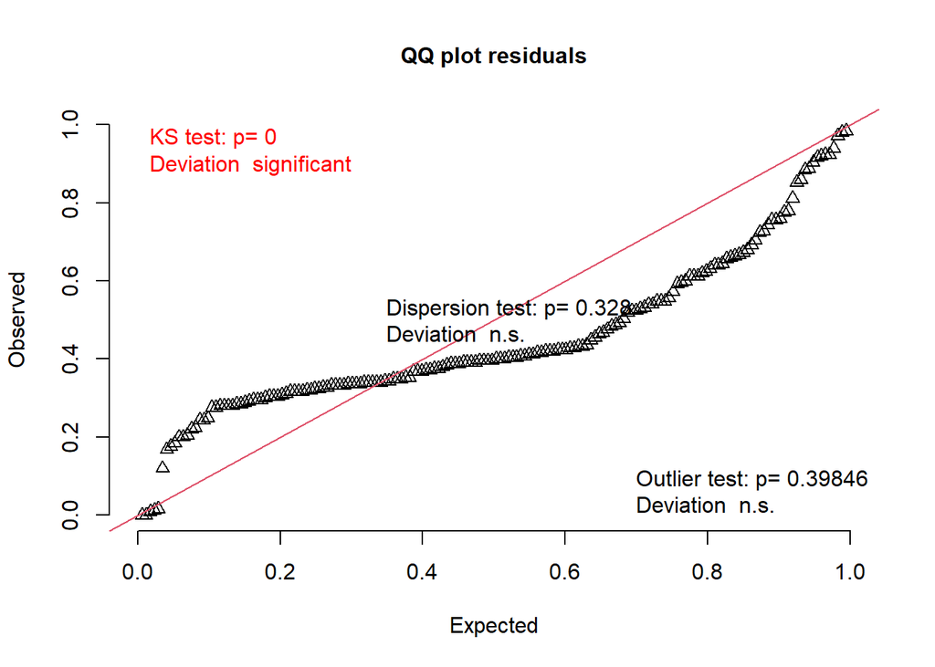

```
##
##  Asymptotic one-sample Kolmogorov-Smirnov test
##
## data:  simulationOutput$scaledResiduals
## D = 0.19772, p-value = 2.888e-06
## alternative hypothesis: two-sided
```

```r
testUniformity(sim_res)
```

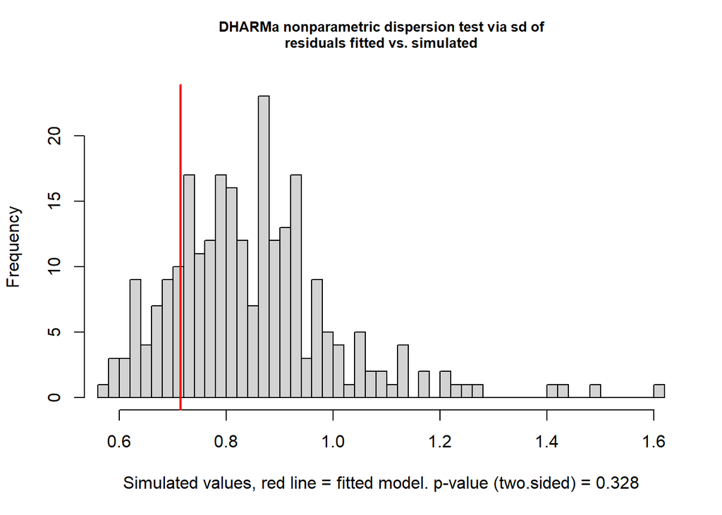

```
##
##  DHARMa nonparametric dispersion test via sd of residuals fitted vs.
##  simulated
##
## data:  simulationOutput
## dispersion = 0.84166, p-value = 0.328
## alternative hypothesis: two.sided
```

```r
testDispersion(sim_res) # No evidence of problematic dispersion, use Wald Z and chi-sq tests
```

```r
model_parameters(m.final)
```

```
## # Fixed Effects
##
## Parameter              | Coefficient |       SE |         95% CI | t(163) |     p
## ---------------------------------------------------------------------------------
## (Intercept)            |       -0.46 |     1.32 | [-3.06,  2.14] |  -0.35 | 0.728
## JanTempMax             |    2.71e-03 |     0.06 | [-0.11,  0.11] |   0.05 | 0.961
## JulyTempMin            |       -0.36 |     0.13 | [-0.61, -0.11] |  -2.87 | 0.005
## RainJuly               |    5.27e-03 | 2.59e-03 | [ 0.00,  0.01] |   2.04 | 0.043
## RainJan                |   -1.88e-03 | 1.97e-03 | [-0.01,  0.00] |  -0.95 | 0.342
## JulyTempMin × RainJuly |    2.21e-03 | 1.01e-03 | [ 0.00,  0.00] |   2.20 | 0.030
##
## # Random Effects
##
## Parameter                   | Coefficient |   SE |       95% CI
## ---------------------------------------------------------------
## SD (Intercept: Studysite)   |        0.46 | 0.11 | [0.29, 0.73]
## SD (Intercept: Year.Finals) |        0.07 | 0.14 | [0.00, 3.83]
## SD (Residual)               |        0.57 | 0.03 | [0.51, 0.64]
```

```
##
## Uncertainty intervals (equal-tailed) and p-values (two-tailed) computed
##   using a Wald t-distribution approximation. Uncertainty intervals for
##   random effect variances computed using a Wald z-distribution
##   approximation.
```

```r
summary(m.final)
```

```
## Linear mixed model fit by REML ['lmerMod']
## Formula: StandardisedAnnualChange.2 ~ JanTempMax + JulyTempMin * RainJuly +
##     RainJan + (1 | Year.Finals) + (1 | Studysite)
##    Data: df_model
##
## REML criterion at convergence: 365.6
##
## Scaled residuals:
##     Min      1Q  Median      3Q     Max
## -5.9319 -0.1946 -0.0655  0.2014  2.7228
##
## Random effects:
##  Groups      Name        Variance Std.Dev.
##  Studysite   (Intercept) 0.212756 0.46125
##  Year.Finals (Intercept) 0.004484 0.06696
##  Residual                0.326411 0.57132
## Number of obs: 172, groups:  Studysite, 24; Year.Finals, 18
##
## Fixed effects:
##                       Estimate Std. Error t value
## (Intercept)          -0.458921   1.316256  -0.349
## JanTempMax            0.002714   0.055772   0.049
## JulyTempMin          -0.360562   0.125475  -2.874
## RainJuly              0.005274   0.002588   2.038
## RainJan              -0.001881   0.001973  -0.953
## JulyTempMin:RainJuly  0.002209   0.001006   2.196
##
## Correlation of Fixed Effects:
##             (Intr) JnTmpM JlyTmM RanJly RainJn
## JanTempMax  -0.974
## JulyTempMin  0.202 -0.037
## RainJuly    -0.358  0.189 -0.717
## RainJan     -0.506  0.476  0.013 -0.080
## JlyTmpMn:RJ -0.022 -0.142 -0.863  0.781 -0.010
```

```r
AIC(m.final)
```

```
## [1] 383.6253
```

#### 1.2. Development of Reduced Climate Model.

```r
m.final2 <-  glmer(StandardisedAnnualChange.2 ~ JulyTempMin * RainJuly + (1 | Year.Finals) + (1 | Studysite), data = df_model)
```

```
## boundary (singular) fit: see help('isSingular')
```

```r
model_parameters(m.final2)
```

```
## # Fixed Effects
##
## Parameter              | Coefficient |       SE |         95% CI | t(165) |     p
## ---------------------------------------------------------------------------------
## (Intercept)            |       -0.46 |     0.28 | [-1.01,  0.09] |  -1.65 | 0.101
## JulyTempMin            |       -0.36 |     0.12 | [-0.59, -0.12] |  -2.98 | 0.003
## RainJuly               |    4.58e-03 | 2.42e-03 | [ 0.00,  0.01] |   1.89 | 0.060
## JulyTempMin × RainJuly |    2.30e-03 | 9.69e-04 | [ 0.00,  0.00] |   2.37 | 0.019
##
## # Random Effects
##
## Parameter                   | Coefficient |     SE |           95% CI
## ---------------------------------------------------------------------
## SD (Intercept: Studysite)   |        0.43 |   0.10 | [0.27,     0.68]
## SD (Intercept: Year.Finals) |    9.74e-06 | 675.69 | [0.00,      Inf]
## SD (Residual)               |        0.58 |   0.03 | [0.51,     0.65]
```

```
##
## Uncertainty intervals (equal-tailed) and p-values (two-tailed) computed
##   using a Wald t-distribution approximation. Uncertainty intervals for
##   random effect variances computed using a Wald z-distribution
##   approximation.
```

```r
summary(m.final2)
```

```
## Linear mixed model fit by REML ['lmerMod']
## Formula:
## StandardisedAnnualChange.2 ~ JulyTempMin * RainJuly + (1 | Year.Finals) +
##     (1 | Studysite)
##    Data: df_model
##
## REML criterion at convergence: 351.8
##
## Scaled residuals:
##     Min      1Q  Median      3Q     Max
## -6.0447 -0.2202 -0.0494  0.2047  2.7000
##
## Random effects:
##  Groups      Name        Variance  Std.Dev.
##  Studysite   (Intercept) 1.844e-01 4.294e-01
##  Year.Finals (Intercept) 9.490e-11 9.742e-06
##  Residual                3.310e-01 5.754e-01
## Number of obs: 172, groups:  Studysite, 24; Year.Finals, 18
##
## Fixed effects:
##                        Estimate Std. Error t value
## (Intercept)          -0.4610379  0.2796359  -1.649
## JulyTempMin          -0.3575446  0.1201286  -2.976
## RainJuly              0.0045814  0.0024224   1.891
## JulyTempMin:RainJuly  0.0022991  0.0009693   2.372
##
## Correlation of Fixed Effects:
##             (Intr) JlyTmM RanJly
## JulyTempMin  0.753
## RainJuly    -0.860 -0.735
## JlyTmpMn:RJ -0.718 -0.886  0.866
## optimizer (nloptwrap) convergence code: 0 (OK)
## boundary (singular) fit: see help('isSingular')
```

```r
AIC(m.final, m.final2)
```

```
##          df      AIC
## m.final   9 383.6253
## m.final2  7 365.8440
```

```r
# Testing performance of final model
MuMIn::r.squaredGLMM(m.final2)
```

```
##             R2m       R2c
## [1,] 0.05801515 0.3950094
```

```
## qu = 0.25, log(sigma) = -3.692393 : outer Newton did not converge fully.
```

```
## qu = 0.25, log(sigma) = -3.696393 : outer Newton did not converge fully.
```

```
## qu = 0.25, log(sigma) = -3.696906 : outer Newton did not converge fully.
```

```
## qu = 0.25, log(sigma) = -3.697242 : outer Newton did not converge fully.
```

```
## qu = 0.25, log(sigma) = -3.697028 : outer Newton did not converge fully.
```

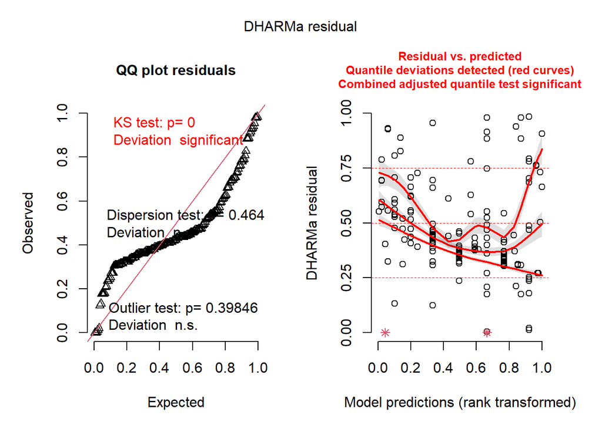

```r
sim_res <- simulateResiduals(m.final2)
plot(sim_res)
```

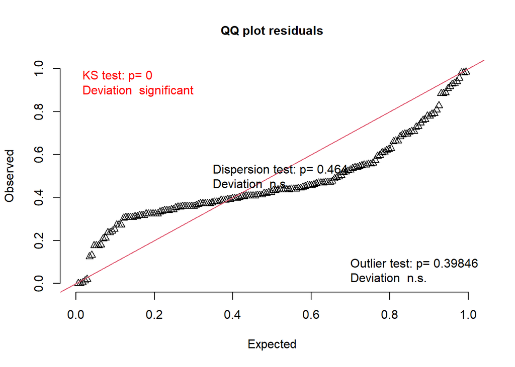

```
##
##  Asymptotic one-sample Kolmogorov-Smirnov test
##
## data:  simulationOutput$scaledResiduals
## D = 0.20163, p-value = 1.688e-06
## alternative hypothesis: two-sided
```

```r
testUniformity(sim_res)
```

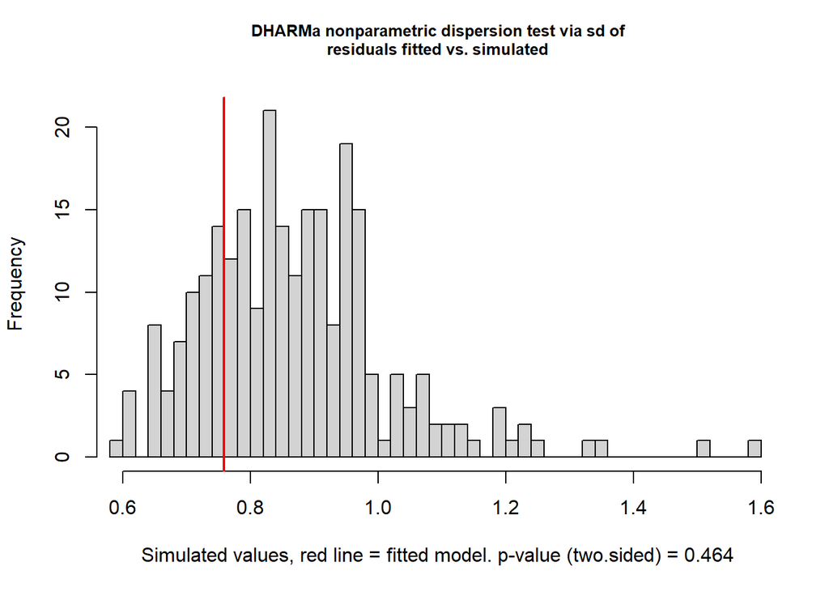

```
##
##  DHARMa nonparametric dispersion test via sd of residuals fitted vs.
##  simulated
##
## data:  simulationOutput
## dispersion = 0.87281, p-value = 0.464
## alternative hypothesis: two.sided
```

```r
testDispersion(sim_res) # No evidence of problematic dispersion, use Wald Z and chi-sq tests
```

```r
model_parameters(m.final2)
```

```
## # Fixed Effects
##
## Parameter              | Coefficient |       SE |         95% CI | t(165) |     p
## ---------------------------------------------------------------------------------
## (Intercept)            |       -0.46 |     0.28 | [-1.01,  0.09] |  -1.65 | 0.101
## JulyTempMin            |       -0.36 |     0.12 | [-0.59, -0.12] |  -2.98 | 0.003
## RainJuly               |    4.58e-03 | 2.42e-03 | [ 0.00,  0.01] |   1.89 | 0.060
## JulyTempMin × RainJuly |    2.30e-03 | 9.69e-04 | [ 0.00,  0.00] |   2.37 | 0.019
##
## # Random Effects
##
## Parameter                   | Coefficient |     SE |           95% CI
## ---------------------------------------------------------------------
## SD (Intercept: Studysite)   |        0.43 |   0.10 | [0.27,     0.68]
## SD (Intercept: Year.Finals) |    9.74e-06 | 675.69 | [0.00,      Inf]
## SD (Residual)               |        0.58 |   0.03 | [0.51,     0.65]
```

```
##
## Uncertainty intervals (equal-tailed) and p-values (two-tailed) computed
##   using a Wald t-distribution approximation. Uncertainty intervals for
##   random effect variances computed using a Wald z-distribution
##   approximation.
```

```r
summary(m.final2)
```

```
## Linear mixed model fit by REML ['lmerMod']
## Formula:
## StandardisedAnnualChange.2 ~ JulyTempMin * RainJuly + (1 | Year.Finals) +
##     (1 | Studysite)
##    Data: df_model
##
## REML criterion at convergence: 351.8
##
## Scaled residuals:
##     Min      1Q  Median      3Q     Max
## -6.0447 -0.2202 -0.0494  0.2047  2.7000
##
## Random effects:
##  Groups      Name        Variance  Std.Dev.
##  Studysite   (Intercept) 1.844e-01 4.294e-01
##  Year.Finals (Intercept) 9.490e-11 9.742e-06
##  Residual                3.310e-01 5.754e-01
## Number of obs: 172, groups:  Studysite, 24; Year.Finals, 18
##
## Fixed effects:
##                        Estimate Std. Error t value
## (Intercept)          -0.4610379  0.2796359  -1.649
## JulyTempMin          -0.3575446  0.1201286  -2.976
## RainJuly              0.0045814  0.0024224   1.891
## JulyTempMin:RainJuly  0.0022991  0.0009693   2.372
##
## Correlation of Fixed Effects:
##             (Intr) JlyTmM RanJly
## JulyTempMin  0.753
## RainJuly    -0.860 -0.735
## JlyTmpMn:RJ -0.718 -0.886  0.866
## optimizer (nloptwrap) convergence code: 0 (OK)
## boundary (singular) fit: see help('isSingular')
```

```r
AIC(m.final)
```

```
## [1] 383.6253
```

```r
AIC(m.final2)
```

```
## [1] 365.844
```

```r
AIC(m.final) - AIC( m.final2)
```

```
## [1] 17.78127
```

```r
# Model validation: check that AIC increases when fixed effect terms are removed
m.final2.NoInteract <-  glmer(StandardisedAnnualChange.2 ~ JulyTempMin + RainJuly + (1 | Year.Finals) + (1 | Studysite), data = df_model)
```

```
## boundary (singular) fit: see help('isSingular')
```

```r
AIC(m.final2.NoInteract )
```

```
## [1] 357.2734
```

```r
model_parameters(m.final2.NoInteract )
```

```
## # Fixed Effects
##
## Parameter   | Coefficient |       SE |        95% CI | t(166) |     p
## ---------------------------------------------------------------------
## (Intercept) |        0.02 |     0.20 | [-0.38, 0.42] |   0.08 | 0.935
## JulyTempMin |       -0.10 |     0.06 | [-0.22, 0.01] |  -1.78 | 0.077
## RainJuly    |   -3.51e-04 | 1.24e-03 | [ 0.00, 0.00] |  -0.28 | 0.777
##
## # Random Effects
##
## Parameter                   | Coefficient |     SE |           95% CI
## ---------------------------------------------------------------------
## SD (Intercept: Studysite)   |        0.47 |   0.11 | [0.30,     0.73]
## SD (Intercept: Year.Finals) |    7.05e-06 | 937.12 | [0.00,      Inf]
## SD (Residual)               |        0.58 |   0.03 | [0.52,     0.65]
```

```
##
## Uncertainty intervals (equal-tailed) and p-values (two-tailed) computed
##   using a Wald t-distribution approximation. Uncertainty intervals for
##   random effect variances computed using a Wald z-distribution
##   approximation.
```

```r
m.final2.reduce.RainJuly <-  glmer(StandardisedAnnualChange.2 ~ RainJuly + (1 | Year.Finals) + (1 | Studysite), data = df_model)
AIC(m.final2.reduce.RainJuly )
```

```
## [1] 353.126
```

```r
model_parameters(m.final2.reduce.RainJuly )
```

```
## # Fixed Effects
##
## Parameter   | Coefficient |       SE |        95% CI | t(167) |     p
## ---------------------------------------------------------------------
## (Intercept) |        0.16 |     0.23 | [-0.29, 0.61] |   0.69 | 0.489
## RainJuly    |    4.15e-04 | 1.55e-03 | [ 0.00, 0.00] |   0.27 | 0.789
##
## # Random Effects
##
## Parameter                   | Coefficient |   SE |       95% CI
## ---------------------------------------------------------------
## SD (Intercept: Studysite)   |        0.56 | 0.12 | [0.37, 0.84]
## SD (Intercept: Year.Finals) |        0.24 | 0.10 | [0.11, 0.53]
## SD (Residual)               |        0.55 | 0.03 | [0.49, 0.62]
```

```
##
## Uncertainty intervals (equal-tailed) and p-values (two-tailed) computed
##   using a Wald t-distribution approximation. Uncertainty intervals for
##   random effect variances computed using a Wald z-distribution
##   approximation.
```

```r
m.final2.JulyTemp <-  lmer(StandardisedAnnualChange.2 ~ JulyTempMin  + (1 | Year.Finals) + (1 | Studysite), data = df_model)
```

```
## boundary (singular) fit: see help('isSingular')
```

```r
AIC(m.final2.JulyTemp)
```

```
## [1] 343.7976
```

```r
model_parameters(m.final2.JulyTemp )
```

```
## # Fixed Effects
##
## Parameter   | Coefficient |   SE |        95% CI | t(167) |     p
## -----------------------------------------------------------------
## (Intercept) |       -0.02 | 0.15 | [-0.32, 0.27] |  -0.15 | 0.882
## JulyTempMin |       -0.10 | 0.06 | [-0.21, 0.01] |  -1.76 | 0.080
##
## # Random Effects
##
## Parameter                   | Coefficient |     SE |           95% CI
## ---------------------------------------------------------------------
## SD (Intercept: Studysite)   |        0.47 |   0.10 | [0.30,     0.72]
## SD (Intercept: Year.Finals) |    1.64e-05 | 382.53 | [0.00,      Inf]
## SD (Residual)               |        0.58 |   0.03 | [0.51,     0.65]
```

```
##
## Uncertainty intervals (equal-tailed) and p-values (two-tailed) computed
##   using a Wald t-distribution approximation. Uncertainty intervals for
##   random effect variances computed using a Wald z-distribution
##   approximation.
```

```r
AIC(m.final2)
```

```
## [1] 365.844
```

```r
model_parameters(m.final2)
```

```
## # Fixed Effects
##
## Parameter              | Coefficient |       SE |         95% CI | t(165) |     p
## ---------------------------------------------------------------------------------
## (Intercept)            |       -0.46 |     0.28 | [-1.01,  0.09] |  -1.65 | 0.101
## JulyTempMin            |       -0.36 |     0.12 | [-0.59, -0.12] |  -2.98 | 0.003
## RainJuly               |    4.58e-03 | 2.42e-03 | [ 0.00,  0.01] |   1.89 | 0.060
## JulyTempMin × RainJuly |    2.30e-03 | 9.69e-04 | [ 0.00,  0.00] |   2.37 | 0.019
##
## # Random Effects
##
## Parameter                   | Coefficient |     SE |           95% CI
## ---------------------------------------------------------------------
## SD (Intercept: Studysite)   |        0.43 |   0.10 | [0.27,     0.68]
## SD (Intercept: Year.Finals) |    9.74e-06 | 675.69 | [0.00,      Inf]
## SD (Residual)               |        0.58 |   0.03 | [0.51,     0.65]
```

```
##
## Uncertainty intervals (equal-tailed) and p-values (two-tailed) computed
##   using a Wald t-distribution approximation. Uncertainty intervals for
##   random effect variances computed using a Wald z-distribution
##   approximation.
```

Plotting the results

```r
median(df_model$JulyTempMin)
```

```
## [1] -1.5
```

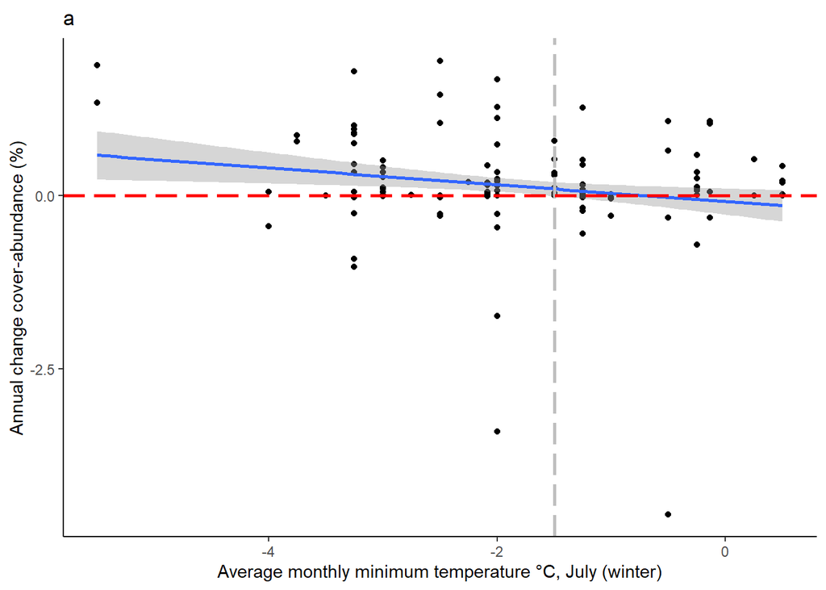

```r
p1.JulyTemp <- ggplot (data = df_model, aes(y = StandardisedAnnualChange.2, x = JulyTempMin)) + geom_point() + geom_smooth(method = lm) + theme_classic() + xlab("Average monthly minimum temperature °C, July (winter)") + ylab("Annual change cover-abundance (%)") + ggtitle("a") + geom_vline(xintercept = -1.5, colour="grey", linetype = "longdash", size= 1)  +  geom_hline(yintercept = 0, colour="red", linetype = "longdash", size= 1)
p1.JulyTemp
```

```r
median(df_model$RainJuly)
```

```
## [1] 118.2904
```

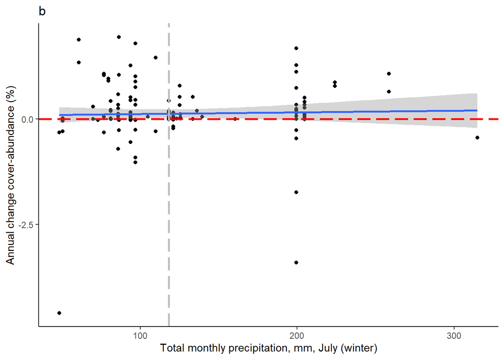

```r
p1.JulyRain <- ggplot (data = df_model, aes(y = StandardisedAnnualChange.2, x = RainJuly)) + geom_point() + geom_smooth(method = lm) + theme_classic() + xlab("Total monthly precipitation, mm, July (winter)") + ylab("Annual change cover-abundance (%)") + ggtitle("b") + geom_vline(xintercept = 118.2904, colour="grey", linetype = "longdash", size= 1)  +  geom_hline(yintercept = 0, colour="red", linetype = "longdash", size= 1)
p1.JulyRain
```

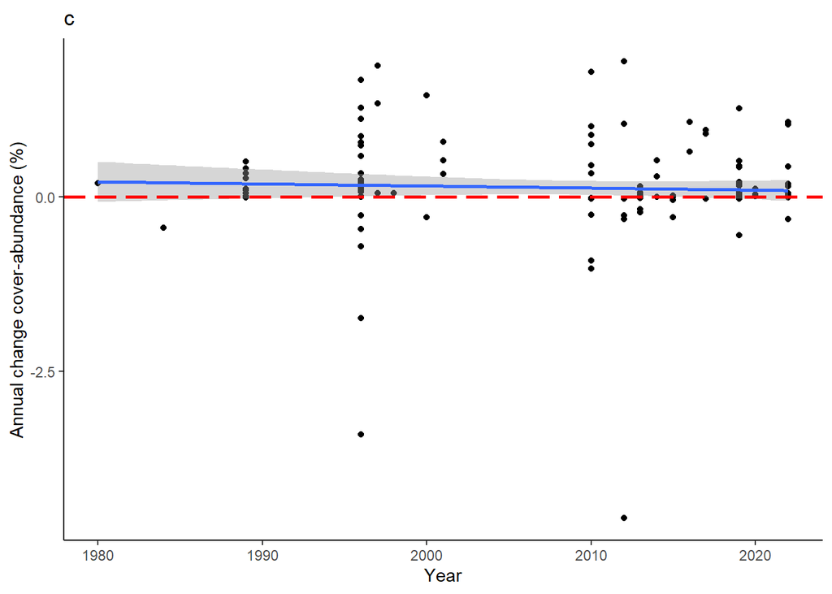

```r
p1.cover <- ggplot (data = df_model, aes(y = StandardisedAnnualChange.2, x = as.numeric(Year.Final))) + geom_point() + geom_smooth(method = lm) + theme_classic() + xlab("Year") + ylab("Annual change cover-abundance (%)") +  geom_hline(yintercept = 0, colour="red", linetype = "longdash", size= 1) + ggtitle("c")
p1.cover
```

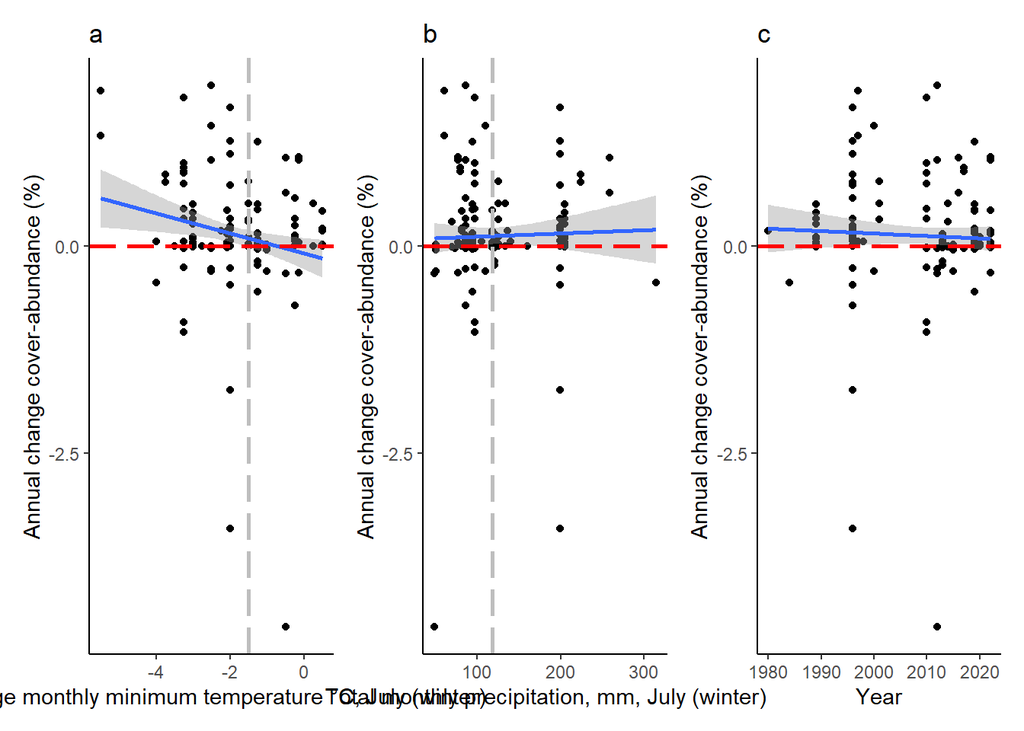

```r
p1.JulyTemp | p1.JulyRain | p1.cover
```

```r
# Cover change through time
corr <- cor.test(x=df_model$Year.Final, y=df_model$StandardisedAnnualChange.2, method = 'spearman')
corr
```

```
##
##  Spearman's rank correlation rho
##
## data:  df_model$Year.Final and df_model$StandardisedAnnualChange.2
## S = 977506, p-value = 0.04559
## alternative hypothesis: true rho is not equal to 0
## sample estimates:
##        rho
## -0.1526566
```

#### 2. Fire GLMM Analysis

Select relevant studies from the dataset related to fire.

```r
df_model <- df_alldata %>% filter (Treatment_Thematic == "Fire" |
                      Treatment_Thematic == "Fire + Grazing" |
                       Treatment_Thematic ==  "Fire + Restoration" |
                      Treatment_Thematic == "Fire + Climate change" ) # Extracts the fire-only related rows
df_model <- df_model %>% filter(Design == "BACI" | Design == "BA") # Omit CI designs, as this doesn't capture rate of change as t0 is not known.
df_model <- df_model %>% filter(Control.Exposure == "Exposure") # Omit Control i.e. unburnt sites.
df_model$TimeSinceFire <- df_model$TimeSinceFire.New # Rename to something more sensible
```

Ensure that all variables are interpreted as the correct data type.

```r
df_model$TimeSinceFire <- as.numeric(df_model$TimeSinceFire)
df_model$StandardisedAnnualChange <- as.numeric(df_model$StandardisedAnnualChange)
df_model$Year.Final <- as.numeric(df_model$Year.Final)
df_model$Year.Initial <- as.numeric(df_model$Year.Initial)
df_model$TimeSpan <- as.numeric(df_model$TimeSpan)
df_model$TimeSinceFire <- as.numeric(df_model$TimeSinceFire)
df_model$Elev_Est_Upper <- as.numeric(df_model$Elev_Est_Upper)
df_model$Elev_Est_Lower <- as.numeric(df_model$Elev_Est_Lower)
df_model$TimeSinceFire <- as.numeric(df_model$TimeSinceFire)
df_model$StandardisedAnnualChange.2<- as.numeric(df_model$StandardisedAnnualChange.2)
```

Identify outliers, and test whether removing outliers improves assumption of normality.

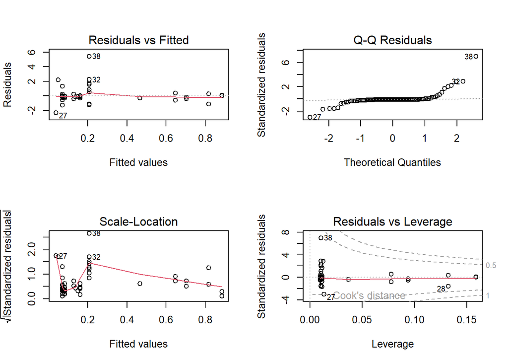

```r
# All values included
lm.test.normalresid <- lm(StandardisedAnnualChange ~ TimeSinceFire, data = df_model)
par(mfrow = c(2, 2))
plot(lm.test.normalresid)
```

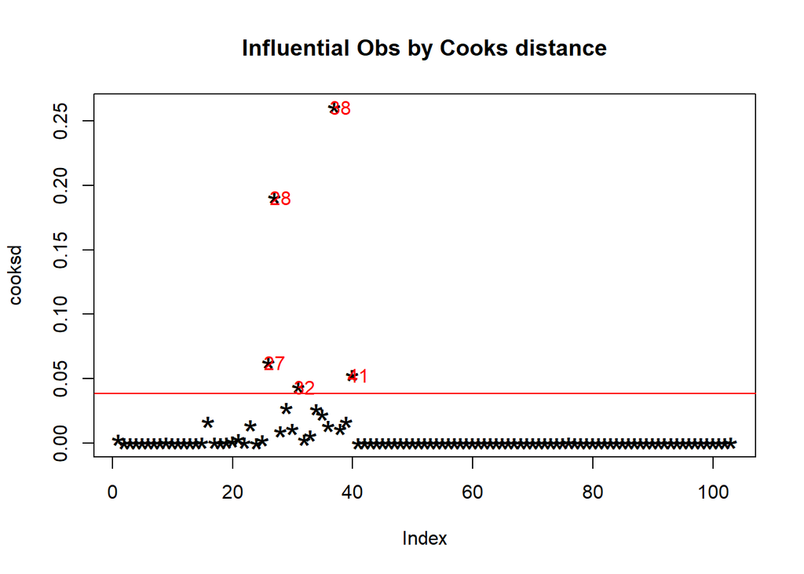

```r
par(mfrow = c(1,1))
cooksd <- cooks.distance(lm.test.normalresid)
sample_size <- nrow(df_model)
plot(cooksd, pch="*", cex=2, main="Influential Obs by Cooks distance")  # plot cook's distance
abline(h = 4/sample_size, col="red")  # add cutoff line
text(x=1:length(cooksd)+1, y=cooksd, labels=ifelse(cooksd>4/sample_size, names(cooksd),""), col="red")  # add labels
```

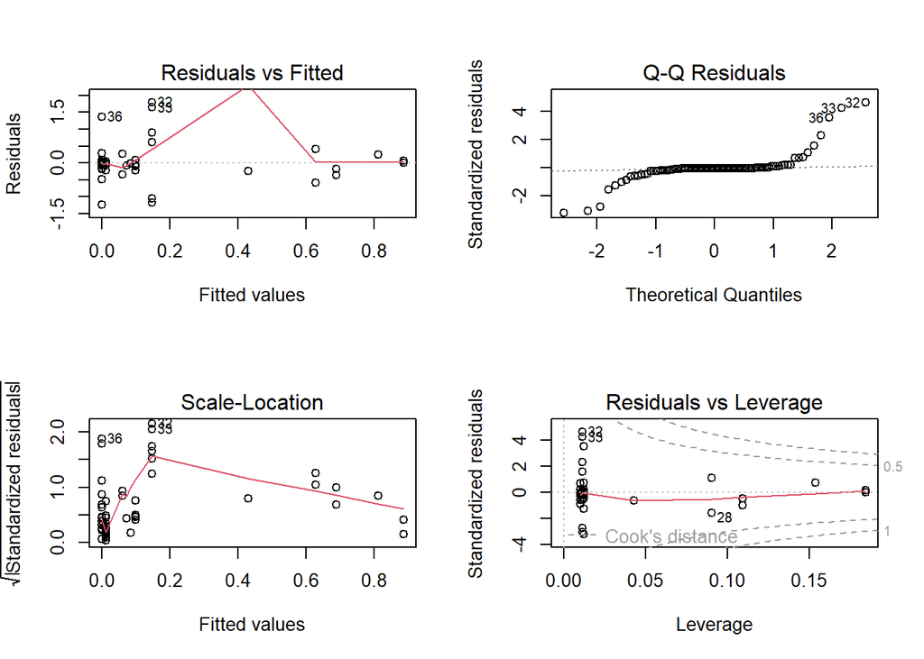

```r
# Identify and remove outliers in a new dataframe
influential <- as.numeric(names(cooksd)[(cooksd > (4/sample_size))])
df_model_no_outlier <- df_model[-influential, ] # Test dataframe
lm.test.normalresid.no.outlier <- lm(StandardisedAnnualChange ~ TimeSinceFire, data = df_model_no_outlier) # Rerun model
par(mfrow = c(2, 2))
plot(lm.test.normalresid.no.outlier) # Look at the results
```

```r
par(mfrow = c(1,1))

shapiro.test(df_model$StandardisedAnnualChange)
```

```
##
##  Shapiro-Wilk normality test
##
## data:  df_model$StandardisedAnnualChange
## W = 0.54467, p-value = 2.458e-16
```

```r
shapiro.test(df_model_no_outlier$StandardisedAnnualChange)
```

```
##
##  Shapiro-Wilk normality test
##
## data:  df_model_no_outlier$StandardisedAnnualChange
## W = 0.63817, p-value = 3.44e-14
```

**Outcome:** both dataframes are non-normal (p << 0.001). Decision to retain all data for full representation of results.

Test of normal distribution of residuals.

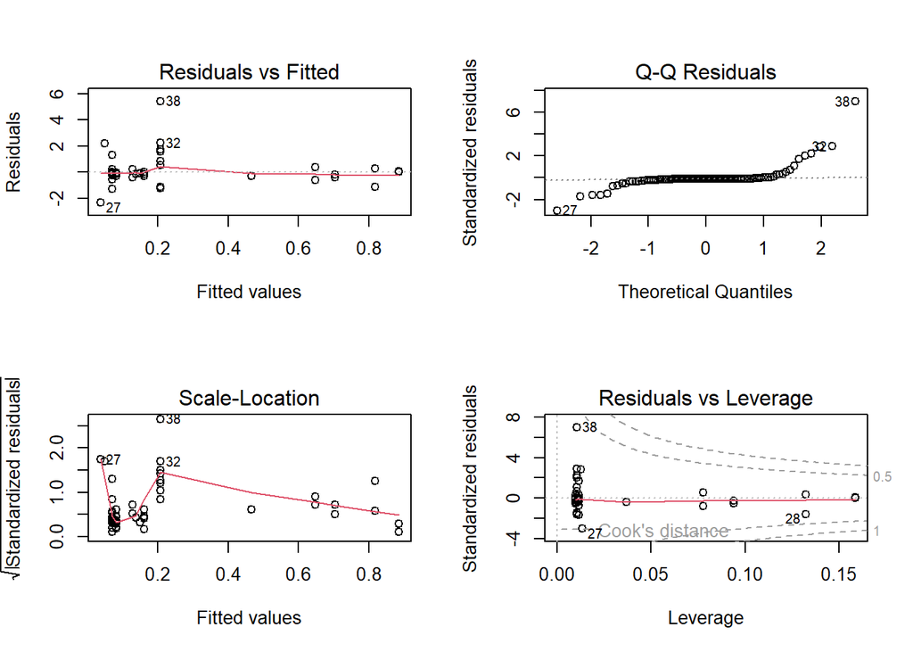

```r
glm.test.normalresid <- glm(StandardisedAnnualChange.2~ TimeSinceFire, data = df_model)
par(mfrow = c(2, 2))
plot(lm.test.normalresid)
```

```r
par(mfrow = c(1,1))
```

**Assessing whether data differs based on study characteristics:** we used the Kruskal-Wallis test to examine whether the annual change in cover-abundance significantly differed between population scales, alpine zones of shrub species and ecosystem types. If p < 0.05, we used Dunn’s test to undertake pairwise comparisions.

```r
# Alpine zone of shrub species
kruskal.test(StandardisedAnnualChange.2 ~ Alpine.Zone, data = df_model)
```

```
##
##  Kruskal-Wallis rank sum test
##
## data:  StandardisedAnnualChange.2 by Alpine.Zone
## Kruskal-Wallis chi-squared = 4.3675, df = 4, p-value = 0.3586
```

```r
# Ecosystem type
kruskal.test(StandardisedAnnualChange.2 ~ Aggregate.InitialES, data = df_model)
```

```
##
##  Kruskal-Wallis rank sum test
##
## data:  StandardisedAnnualChange.2 by Aggregate.InitialES
## Kruskal-Wallis chi-squared = 24.97, df = 8, p-value = 0.001573
```

```r
dunnTest(StandardisedAnnualChange.2 ~ Aggregate.InitialES, data = df_model, method="bh")
```

```
## Dunn (1964) Kruskal-Wallis multiple comparison
```

```
##   p-values adjusted with the Benjamini-Hochberg method.
```

```
##                                                      Comparison           Z
## 1  Cushion heathland / Fjaledmark - Grassland (dry) / Herbfield -0.84093952
## 2  Cushion heathland / Fjaledmark - Grassland (wet) / Herbfield -1.56226732
## 3     Grassland (dry) / Herbfield - Grassland (wet) / Herbfield -0.96301139
## 4              Cushion heathland / Fjaledmark - Heathland (dry) -0.71582390
## 5                 Grassland (dry) / Herbfield - Heathland (dry)  0.39752455
## 6                 Grassland (wet) / Herbfield - Heathland (dry)  1.43761299
## 7  Cushion heathland / Fjaledmark - Heathland (dry) / Grassland -1.88313175
## 8     Grassland (dry) / Herbfield - Heathland (dry) / Grassland -1.21436196
## 9     Grassland (wet) / Herbfield - Heathland (dry) / Grassland  0.26399931
## 10                Heathland (dry) - Heathland (dry) / Grassland -3.60434511
## 11             Cushion heathland / Fjaledmark - Heathland (wet) -2.18414282
## 12                Grassland (dry) / Herbfield - Heathland (wet) -1.63044817
## 13                Grassland (wet) / Herbfield - Heathland (wet) -0.20801360
## 14                            Heathland (dry) - Heathland (wet) -3.10391789
```

[output cut: 59 more lines]

**Testing model requirement:**

1. That > 10-20 samples per treatment - this is met as all samples have temperature, rainfall and final sampling year.
2. That categorical variables have at least six levels. See code below.

```r
n_distinct(df_model$Study) # > 6
```

```
## [1] 13
```

```r
n_distinct(df_model$Studysite) # > 6
```

```
## [1] 11
```

```r
n_distinct(df_model$Response.Level) # < 6 levels, omit
```

```
## [1] 3
```

Correlation plot of numerical data.

```r
subset_corrdata <- df_model[, c("StandardisedAnnualChange.2",
                                "Elev_Est_Lower",
                                "Elev_Est_Upper",
                                "Year.Initial",
                                "Year.Final",
                                "TimeSinceFire",
                                "RainJan",
                                "RainJuly",
                                "JanTempMax",
                                "JanTempMin",
                                "JulyTempMax",
                                "JulyTempMin")]
res <- cor(subset_corrdata)
round(res, 2)
```

```
##                            StandardisedAnnualChange.2 Elev_Est_Lower
## StandardisedAnnualChange.2                       1.00           0.11
## Elev_Est_Lower                                   0.11           1.00
## Elev_Est_Upper                                  -0.06           0.56
## Year.Initial                                    -0.05          -0.28
## Year.Final                                       0.11           0.03
## TimeSinceFire                                    0.24           0.29
## RainJan                                         -0.13           0.43
## RainJuly                                        -0.42          -0.03
## JanTempMax                                       0.06          -0.21
## JanTempMin                                       0.12           0.02
## JulyTempMax                                      0.03          -0.45
## JulyTempMin                                     -0.04          -0.23
##                            Elev_Est_Upper Year.Initial Year.Final TimeSinceFire
## StandardisedAnnualChange.2          -0.06        -0.05       0.11          0.24
## Elev_Est_Lower                       0.56        -0.28       0.03          0.29
## Elev_Est_Upper                       1.00         0.21      -0.10         -0.20
## Year.Initial                         0.21         1.00       0.49         -0.66
## Year.Final                          -0.10         0.49       1.00          0.07
## TimeSinceFire                       -0.20        -0.66       0.07          1.00
## RainJan                              0.14        -0.25      -0.44         -0.02
## RainJuly                             0.13        -0.10      -0.55         -0.32
## JanTempMax                          -0.01         0.25       0.38         -0.04
## JanTempMin                           0.09         0.10       0.24          0.06
## JulyTempMax                         -0.63        -0.08       0.47          0.28
## JulyTempMin                         -0.39        -0.10       0.30          0.13
##                            RainJan RainJuly JanTempMax JanTempMin JulyTempMax
## StandardisedAnnualChange.2   -0.13    -0.42       0.06       0.12        0.03
## Elev_Est_Lower                0.43    -0.03      -0.21       0.02       -0.45
## Elev_Est_Upper                0.14     0.13      -0.01       0.09       -0.63
## Year.Initial                 -0.25    -0.10       0.25       0.10       -0.08
## Year.Final                   -0.44    -0.55       0.38       0.24        0.47
## TimeSinceFire                -0.02    -0.32      -0.04       0.06        0.28
## RainJan                       1.00     0.51      -0.70      -0.56       -0.64
## RainJuly                      0.51     1.00      -0.04       0.02       -0.23
## JanTempMax                   -0.70    -0.04       1.00       0.92        0.59
## JanTempMin                   -0.56     0.02       0.92       1.00        0.47
## JulyTempMax                  -0.64    -0.23       0.59       0.47        1.00
## JulyTempMin                  -0.54     0.07       0.73       0.74        0.86
##                            JulyTempMin
## StandardisedAnnualChange.2       -0.04
## Elev_Est_Lower                   -0.23
## Elev_Est_Upper                   -0.39
## Year.Initial                     -0.10
## Year.Final                        0.30
## TimeSinceFire                     0.13
## RainJan                          -0.54
## RainJuly                          0.07
## JanTempMax                        0.73
## JanTempMin                        0.74
## JulyTempMax                       0.86
## JulyTempMin                       1.00
```

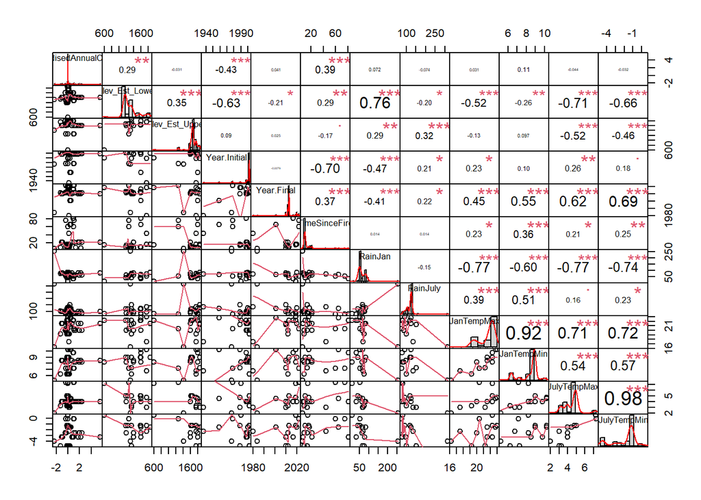

```r
p_corrchart <- chart.Correlation(subset_corrdata[,1:12], histogram=TRUE, method = c("spearman"), pch="19", exact = FALSE)
```

#### 2.1. Fire Model

```r
m1.null <- lmer(StandardisedAnnualChange ~ 1 + (1 | JanTempMax) + (1 | Year.Final) + (1 | RainJuly) + (1 | Elev_Est_Lower), data = df_model, REML = FALSE)
```

```
## boundary (singular) fit: see help('isSingular')
```

```r
summary(m1.null)
```

```
## Linear mixed model fit by maximum likelihood  ['lmerMod']
## Formula: StandardisedAnnualChange ~ 1 + (1 | JanTempMax) + (1 | Year.Final) +
##     (1 | RainJuly) + (1 | Elev_Est_Lower)
##    Data: df_model
##
##      AIC      BIC   logLik deviance df.resid
##    229.9    245.7   -109.0    217.9       97
##
## Scaled residuals:
##     Min      1Q  Median      3Q     Max
## -3.8065 -0.0259  0.0008  0.0087  6.6461
##
## Random effects:
##  Groups         Name        Variance Std.Dev.
##  RainJuly       (Intercept) 0.0000   0.0000
##  Elev_Est_Lower (Intercept) 0.3815   0.6177
##  Year.Final     (Intercept) 0.0000   0.0000
##  JanTempMax     (Intercept) 0.0000   0.0000
##  Residual                   0.4038   0.6355
## Number of obs: 103, groups:
## RainJuly, 13; Elev_Est_Lower, 12; Year.Final, 10; JanTempMax, 10
##
## Fixed effects:
##             Estimate Std. Error t value
## (Intercept)   0.1051     0.2128   0.494
## optimizer (nloptwrap) convergence code: 0 (OK)
## boundary (singular) fit: see help('isSingular')
```

```r
anova(m1.null)
```

```
## Analysis of Variance Table
##      npar Sum Sq Mean Sq F value
```

```r
m.final <- m1.null

# Testing performance of final model
MuMIn::r.squaredGLMM(m.final)
```

```
##      R2m       R2c
## [1,]   0 0.4857761
```

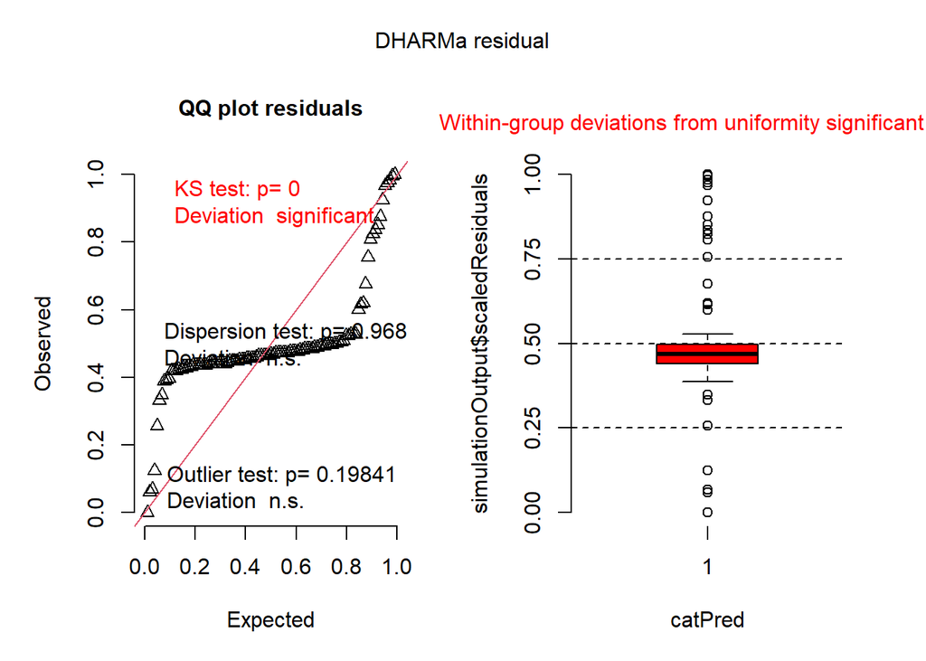

```r
sim_res <- simulateResiduals(m.final)
plot(sim_res)
```

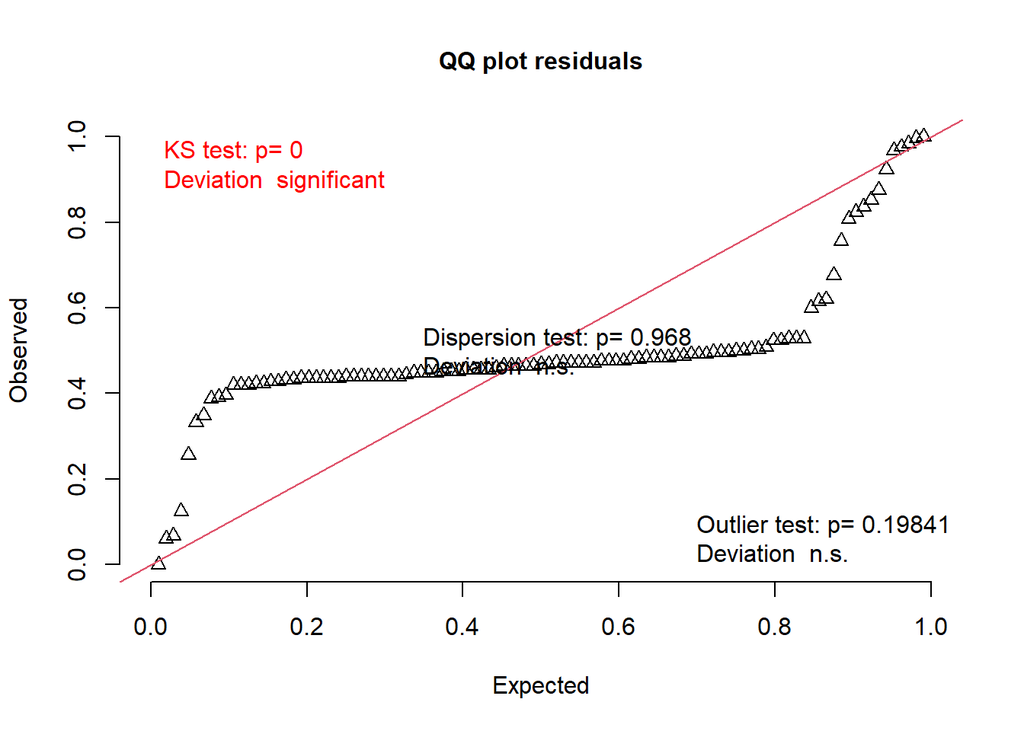

```
##
##  Asymptotic one-sample Kolmogorov-Smirnov test
##
## data:  simulationOutput$scaledResiduals
## D = 0.32291, p-value = 9.383e-10
## alternative hypothesis: two-sided
```

```r
testUniformity(sim_res)
```

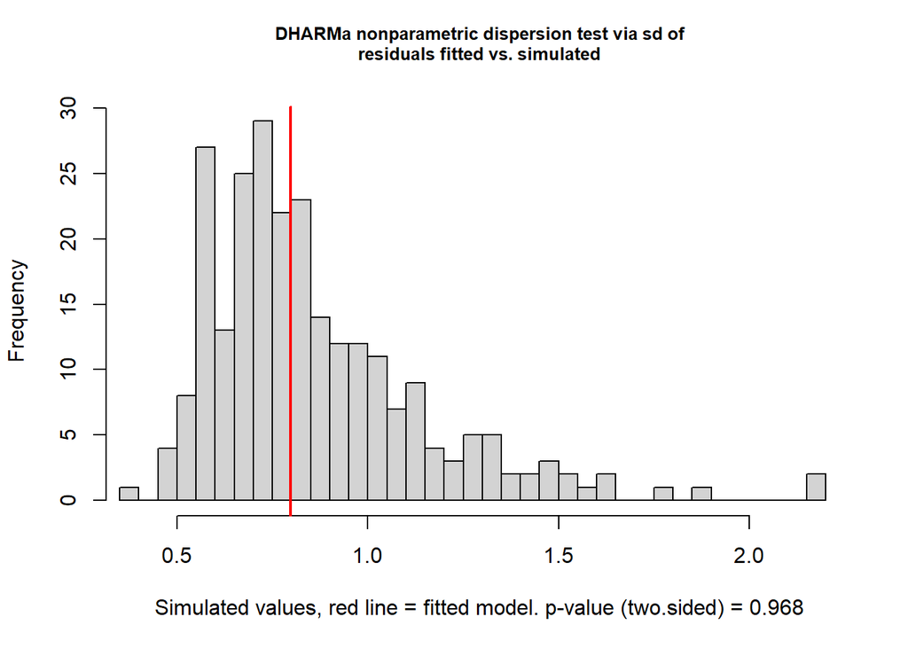

```
##
##  DHARMa nonparametric dispersion test via sd of residuals fitted vs.
##  simulated
##
## data:  simulationOutput
## dispersion = 0.92774, p-value = 0.968
## alternative hypothesis: two.sided
```

```r
testDispersion(sim_res) # No evidence of problematic dispersion, use Wald Z and chi-sq tests
```

```r
model_parameters(m.final)
```

```
## # Fixed Effects
##
## Parameter   | Coefficient |   SE |        95% CI | t(97) |     p
## ----------------------------------------------------------------
## (Intercept) |        0.11 | 0.21 | [-0.32, 0.53] |  0.49 | 0.623
##
## # Random Effects
##
## Parameter                      | Coefficient
## --------------------------------------------
## SD (Intercept: RainJuly)       |        0.00
## SD (Intercept: Elev_Est_Lower) |        0.62
## SD (Intercept: Year.Final)     |        0.00
## SD (Intercept: JanTempMax)     |        0.00
## SD (Residual)                  |        0.64
```

```
##
## Uncertainty intervals (equal-tailed) and p-values (two-tailed) computed
##   using a Wald t-distribution approximation. Uncertainty intervals for
##   random effect variances computed using a Wald z-distribution
##   approximation.
```

```r
summary(m.final)
```

```
## Linear mixed model fit by maximum likelihood  ['lmerMod']
## Formula: StandardisedAnnualChange ~ 1 + (1 | JanTempMax) + (1 | Year.Final) +
##     (1 | RainJuly) + (1 | Elev_Est_Lower)
##    Data: df_model
##
##      AIC      BIC   logLik deviance df.resid
##    229.9    245.7   -109.0    217.9       97
##
## Scaled residuals:
##     Min      1Q  Median      3Q     Max
## -3.8065 -0.0259  0.0008  0.0087  6.6461
##
## Random effects:
##  Groups         Name        Variance Std.Dev.
##  RainJuly       (Intercept) 0.0000   0.0000
##  Elev_Est_Lower (Intercept) 0.3815   0.6177
##  Year.Final     (Intercept) 0.0000   0.0000
##  JanTempMax     (Intercept) 0.0000   0.0000
##  Residual                   0.4038   0.6355
## Number of obs: 103, groups:
## RainJuly, 13; Elev_Est_Lower, 12; Year.Final, 10; JanTempMax, 10
##
## Fixed effects:
##             Estimate Std. Error t value
## (Intercept)   0.1051     0.2128   0.494
## optimizer (nloptwrap) convergence code: 0 (OK)
## boundary (singular) fit: see help('isSingular')
```

#### 2.2. Fire Trait Model

```r
# Forward selection procedure for random effects
m1 <- glmer(StandardisedAnnualChange ~ TimeSinceFire + Seeder.Resprouter2 + (1 | JanTempMax) + 1, data = df_model)
m2 <- glmer(StandardisedAnnualChange ~ TimeSinceFire + Seeder.Resprouter2 + (1 | JanTempMax) + (1 | Year.Final) + 1, data = df_model)
m3 <- glmer(StandardisedAnnualChange ~ TimeSinceFire + Seeder.Resprouter2 + (1 | JanTempMax) + (1 | Year.Final) + (1 | RainJuly) + 1, data = df_model)
```

```
## boundary (singular) fit: see help('isSingular')
```

```r
m4 <- glmer(StandardisedAnnualChange ~ TimeSinceFire + Seeder.Resprouter2 + (1 | JanTempMax) + (1 | RainJuly) + 1, data = df_model)
```

```
## boundary (singular) fit: see help('isSingular')
```

```r
m5 <- glmer(StandardisedAnnualChange ~ TimeSinceFire + Seeder.Resprouter2 + (1 | JanTempMax) + (1 | Year.Final) + (1 | RainJuly) + (1 | Elev_Est_Lower) + 1, data = df_model)
```

```
## boundary (singular) fit: see help('isSingular')
```

```r
m6 <- glmer(StandardisedAnnualChange ~ TimeSinceFire + Seeder.Resprouter2 + (1 | Year.Final) + (1 | RainJuly) + (1 | Elev_Est_Lower) + 1, data = df_model)
```

```
## boundary (singular) fit: see help('isSingular')
```

```r
m7 <- glmer(StandardisedAnnualChange ~ TimeSinceFire + Seeder.Resprouter2 + (1 | JanTempMax) + (1 | Year.Final) + (1 | Elev_Est_Lower) + 1, data = df_model)
```

```
## boundary (singular) fit: see help('isSingular')
```

```r
m8 <- glmer(StandardisedAnnualChange ~ TimeSinceFire + Seeder.Resprouter2 + (1 | Year.Final) + (1 | RainJuly) + (1 | Elev_Est_Lower) + 1, data = df_model)
```

```
## boundary (singular) fit: see help('isSingular')
```

```r
m9 <- glmer(StandardisedAnnualChange ~ TimeSinceFire + Seeder.Resprouter2 + (1 | RainJuly) + (1 | Elev_Est_Lower) + 1, data = df_model)
```

```
## boundary (singular) fit: see help('isSingular')
```

```r
AIC(m1, m2, m3, m4, m5, m6, m7, m8, m9, m1.null) # m.null lowest AIC, with m9 lowest AIC of all Fire Trait Model iterations.
```

```
##         df      AIC
## m1       7 258.2644
## m2       8 253.1576
## m3       9 253.7961
## m4       8 251.7961
## m5      10 244.1804
## m6       9 242.1804
## m7       9 242.1804
## m8       9 242.1804
## m9       8 240.1804
## m1.null  6 229.9159
```

```r
anova(m1, m2, m3, m4, m5, m6, m7, m8, m9, m1.null)
```

```
## refitting model(s) with ML (instead of REML)
```

```
## Data: df_model
## Models:
## m1.null: StandardisedAnnualChange ~ 1 + (1 | JanTempMax) + (1 | Year.Final) + (1 | RainJuly) + (1 | Elev_Est_Lower)
## m1: StandardisedAnnualChange ~ TimeSinceFire + Seeder.Resprouter2 + (1 | JanTempMax) + 1
## m2: StandardisedAnnualChange ~ TimeSinceFire + Seeder.Resprouter2 + (1 | JanTempMax) + (1 | Year.Final) + 1
## m4: StandardisedAnnualChange ~ TimeSinceFire + Seeder.Resprouter2 + (1 | JanTempMax) + (1 | RainJuly) + 1
## m9: StandardisedAnnualChange ~ TimeSinceFire + Seeder.Resprouter2 + (1 | RainJuly) + (1 | Elev_Est_Lower) + 1
## m3: StandardisedAnnualChange ~ TimeSinceFire + Seeder.Resprouter2 + (1 | JanTempMax) + (1 | Year.Final) + (1 | RainJuly) + 1
## m6: StandardisedAnnualChange ~ TimeSinceFire + Seeder.Resprouter2 + (1 | Year.Final) + (1 | RainJuly) + (1 | Elev_Est_Lower) + 1
## m7: StandardisedAnnualChange ~ TimeSinceFire + Seeder.Resprouter2 + (1 | JanTempMax) + (1 | Year.Final) + (1 | Elev_Est_Lower) + 1
## m8: StandardisedAnnualChange ~ TimeSinceFire + Seeder.Resprouter2 + (1 | Year.Final) + (1 | RainJuly) + (1 | Elev_Est_Lower) + 1
## m5: StandardisedAnnualChange ~ TimeSinceFire + Seeder.Resprouter2 + (1 | JanTempMax) + (1 | Year.Final) + (1 | RainJuly) + (1 | Elev_Est_Lower) + 1
##         npar    AIC    BIC  logLik deviance   Chisq Df Pr(>Chisq)
## m1.null    6 229.92 245.72 -108.96   217.92
## m1         7 244.79 263.23 -115.39   230.79  0.0000  1    1.00000
## m2         8 240.75 261.82 -112.37   224.75  6.0392  1    0.01399 *
## m4         8 238.74 259.81 -111.37   222.74  2.0122  0
## m9         8 226.85 247.93 -105.43   210.85 11.8806  0
## m3         9 240.74 264.45 -111.37   222.74  0.0000  1    1.00000
## m6         9 228.85 252.57 -105.43   210.85 11.8806  0
## m7         9 228.85 252.57 -105.43   210.85  0.0000  0
## m8         9 228.85 252.57 -105.43   210.85  0.0000  0
## m5        10 230.85 257.20 -105.43   210.85  0.0000  1    1.00000
## ---
## Signif. codes:  0 '***' 0.001 '**' 0.01 '*' 0.05 '.' 0.1 ' ' 1
```

```r
summary(m9)
```

```
## Linear mixed model fit by REML ['lmerMod']
## Formula: StandardisedAnnualChange ~ TimeSinceFire + Seeder.Resprouter2 +
##     (1 | RainJuly) + (1 | Elev_Est_Lower) + 1
##    Data: df_model
##
## REML criterion at convergence: 224.2
##
## Scaled residuals:
##     Min      1Q  Median      3Q     Max
## -3.8319 -0.2774  0.1410  0.1682  6.3313
##
## Random effects:
##  Groups         Name        Variance Std.Dev.
##  RainJuly       (Intercept) 0.0000   0.0000
##  Elev_Est_Lower (Intercept) 0.4160   0.6450
##  Residual                   0.3929   0.6268
## Number of obs: 103, groups:  RainJuly, 13; Elev_Est_Lower, 12
##
## Fixed effects:
##                                      Estimate Std. Error t value
## (Intercept)                         -0.222301   0.288043  -0.772
## TimeSinceFire                        0.012245   0.006437   1.902
## Seeder.Resprouter2No fire tolerance  0.090381   0.352139   0.257
## Seeder.Resprouter2Obligate Seeder    0.258208   0.258891   0.997
## Seeder.Resprouter2Resprouter        -0.013990   0.246442  -0.057
##
## Correlation of Fixed Effects:
##             (Intr) TmSncF S.R2ft S.R2OS
## TimeSinceFr -0.534
## Sdr.Rsp2Nft -0.306  0.054
## Sdr.Rspr2OS -0.361  0.050  0.568
## Sdr.Rsprt2R -0.378  0.052  0.598  0.821
## optimizer (nloptwrap) convergence code: 0 (OK)
## boundary (singular) fit: see help('isSingular')
```

```r
m.final <- m9
```

```r
# Testing performance of final model
MuMIn::r.squaredGLMM(m.final)
```

```
##             R2m       R2c
## [1,] 0.05510687 0.5410708
```

```
## qu = 0.5, log(sigma) = -4.048457 : outer Newton did not converge fully.
```

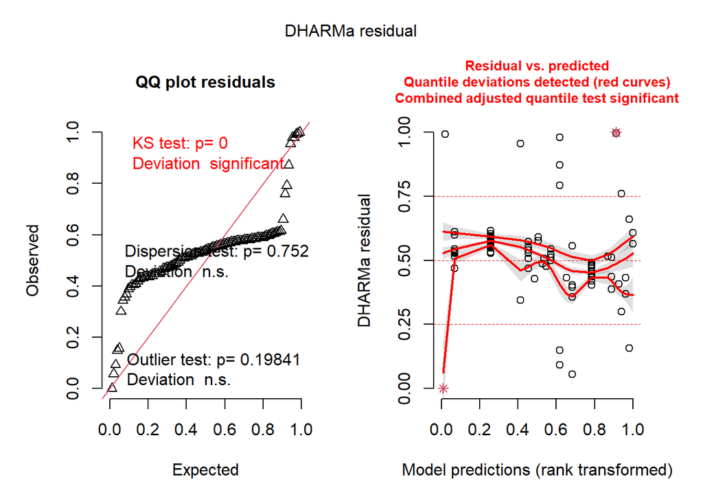

```r
sim_res <- simulateResiduals(m.final)
plot(sim_res)
```

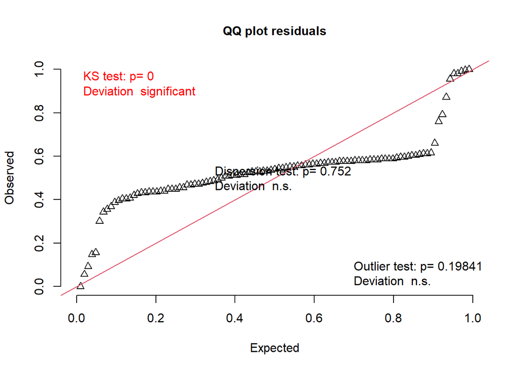

```
##
##  Asymptotic one-sample Kolmogorov-Smirnov test
##
## data:  simulationOutput$scaledResiduals
## D = 0.30062, p-value = 1.644e-08
## alternative hypothesis: two-sided
```

```r
testUniformity(sim_res)
```

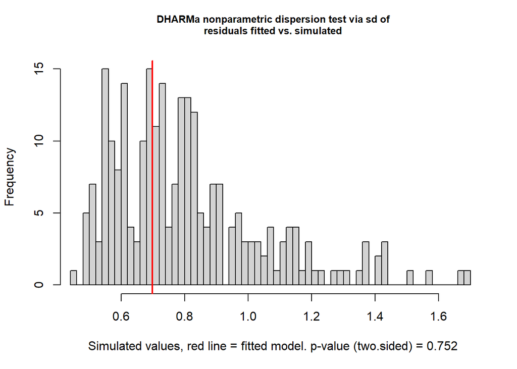

```
##
##  DHARMa nonparametric dispersion test via sd of residuals fitted vs.
##  simulated
##
## data:  simulationOutput
## dispersion = 0.8635, p-value = 0.752
## alternative hypothesis: two.sided
```

```r
testDispersion(sim_res) # No evidence of problematic dispersion, use Wald Z and chi-sq tests
```

```r
model_parameters(m.final)
```

```
## Cannot compute standard errors and confidence intervals for random
##   effects parameters.
##   Your model may suffer from singularity (see see `?lme4::isSingular` and
##   `?performance::check_singularity`).
##   You may try to impose a prior on the random effects parameters, e.g.
##   using the glmmTMB package.
```

```
## # Fixed Effects
##
## Parameter                              | Coefficient |       SE |        95% CI
## -------------------------------------------------------------------------------
## (Intercept)                            |       -0.22 |     0.29 | [-0.79, 0.35]
## TimeSinceFire                          |        0.01 | 6.44e-03 | [ 0.00, 0.03]
## Seeder Resprouter2 [No fire tolerance] |        0.09 |     0.35 | [-0.61, 0.79]
## Seeder Resprouter2 [Obligate Seeder]   |        0.26 |     0.26 | [-0.26, 0.77]
## Seeder Resprouter2 [Resprouter]        |       -0.01 |     0.25 | [-0.50, 0.48]
##
## Parameter                              | t(95) |     p
## ------------------------------------------------------
## (Intercept)                            | -0.77 | 0.442
## TimeSinceFire                          |  1.90 | 0.060
## Seeder Resprouter2 [No fire tolerance] |  0.26 | 0.798
## Seeder Resprouter2 [Obligate Seeder]   |  1.00 | 0.321
## Seeder Resprouter2 [Resprouter]        | -0.06 | 0.955
##
## # Random Effects
##
## Parameter                      | Coefficient
## --------------------------------------------
## SD (Intercept: RainJuly)       |        0.00
## SD (Intercept: Elev_Est_Lower) |        0.64
## SD (Residual)                  |        0.63
```

```
##
## Uncertainty intervals (equal-tailed) and p-values (two-tailed) computed
##   using a Wald t-distribution approximation. Uncertainty intervals for
##   random effect variances computed using a Wald z-distribution
##   approximation.
```

```r
summary(m.final)
```

```
## Linear mixed model fit by REML ['lmerMod']
## Formula: StandardisedAnnualChange ~ TimeSinceFire + Seeder.Resprouter2 +
##     (1 | RainJuly) + (1 | Elev_Est_Lower) + 1
##    Data: df_model
##
## REML criterion at convergence: 224.2
##
## Scaled residuals:
##     Min      1Q  Median      3Q     Max
## -3.8319 -0.2774  0.1410  0.1682  6.3313
##
## Random effects:
##  Groups         Name        Variance Std.Dev.
##  RainJuly       (Intercept) 0.0000   0.0000
##  Elev_Est_Lower (Intercept) 0.4160   0.6450
##  Residual                   0.3929   0.6268
## Number of obs: 103, groups:  RainJuly, 13; Elev_Est_Lower, 12
##
## Fixed effects:
##                                      Estimate Std. Error t value
## (Intercept)                         -0.222301   0.288043  -0.772
## TimeSinceFire                        0.012245   0.006437   1.902
## Seeder.Resprouter2No fire tolerance  0.090381   0.352139   0.257
## Seeder.Resprouter2Obligate Seeder    0.258208   0.258891   0.997
## Seeder.Resprouter2Resprouter        -0.013990   0.246442  -0.057
##
## Correlation of Fixed Effects:
##             (Intr) TmSncF S.R2ft S.R2OS
## TimeSinceFr -0.534
## Sdr.Rsp2Nft -0.306  0.054
## Sdr.Rspr2OS -0.361  0.050  0.568
## Sdr.Rsprt2R -0.378  0.052  0.598  0.821
## optimizer (nloptwrap) convergence code: 0 (OK)
## boundary (singular) fit: see help('isSingular')
```